# Question

Una vez inicia la migración del sardina en una cierta región del país, su pesca varía diariamente según la expresión:

$$P = -d^2 + 11d + -20$$

Donde $P$ representa la pesca, en toneladas, y $d$ los días transcurridos después de iniciada la migración.

¿Cuál de las siguientes gráficas muestra correctamente la relación entre la pesca y los días transcurridos después de iniciada la migración?

## Answerlist

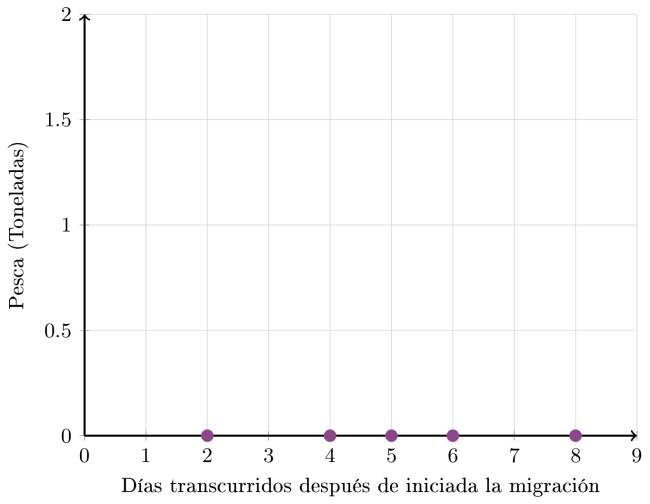

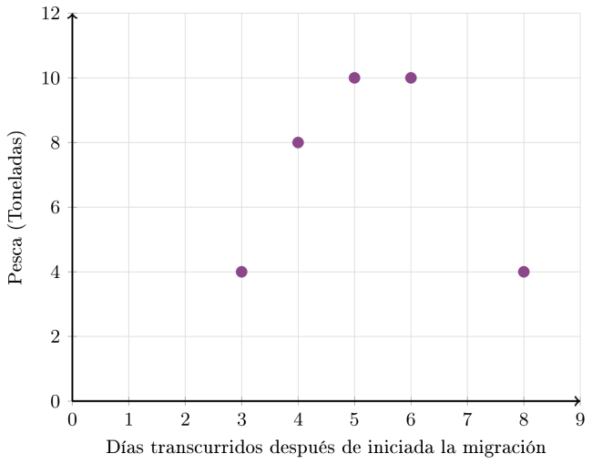

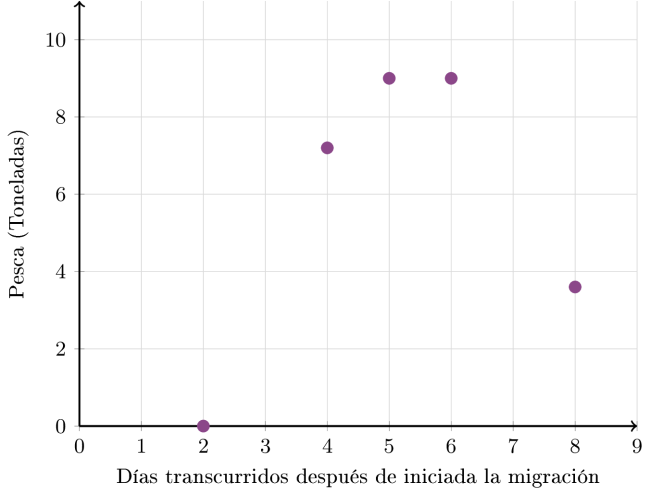

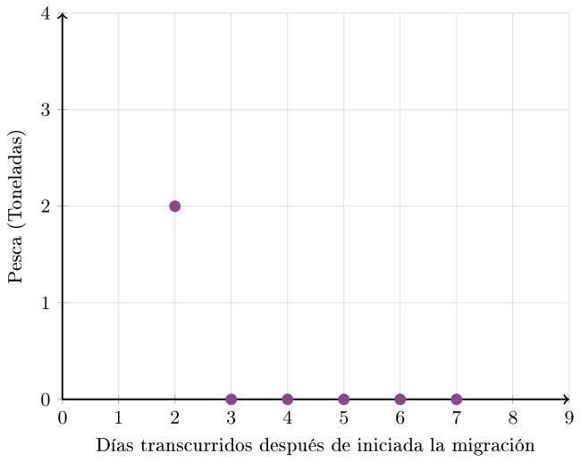

# Solution

Para resolver este problema, debemos identificar cuál gráfica representa correctamente la función cuadrática $P = -d^2 + 11d + -20$.

**Análisis de la función:**

1. **Tipo de función**: Es una función cuadrática (parabólica)
2. **Coeficiente principal**: $a = -1$ (negativo), por lo que la parábola **abre hacia abajo** (forma de U invertida)
3. **Vértice (máximo)**: Ocurre en $d = \frac{-b}{2a} = \frac{11}{2} = 5.5$ días
4. **Valor máximo**: $P_{max} \approx 10.2$ toneladas

**Características que debe tener la gráfica correcta:**

- Parábola invertida (forma de U invertida)
- Máximo alrededor del día 5.5
- Los valores de pesca aumentan hasta el día del vértice y luego disminuyen
- Todos los puntos deben estar sobre o cerca de la curva parabólica

**Verificación con punto del vértice:**

Para $d = 5.5$: $P \approx 10.2$ toneladas (valor máximo)

# Meta-information

exname: Migración Atún Representación Gráfica Función Cuadrática OPTIMIZADO extype: schoice exsolution: 0100 exshuffle: TRUE exsection: Estadística/Interpretación de Gráficas/Funciones Cuadráticas